# Gulf of Maine Warming Update: 2024

### Bottom Temperatures from Buoys

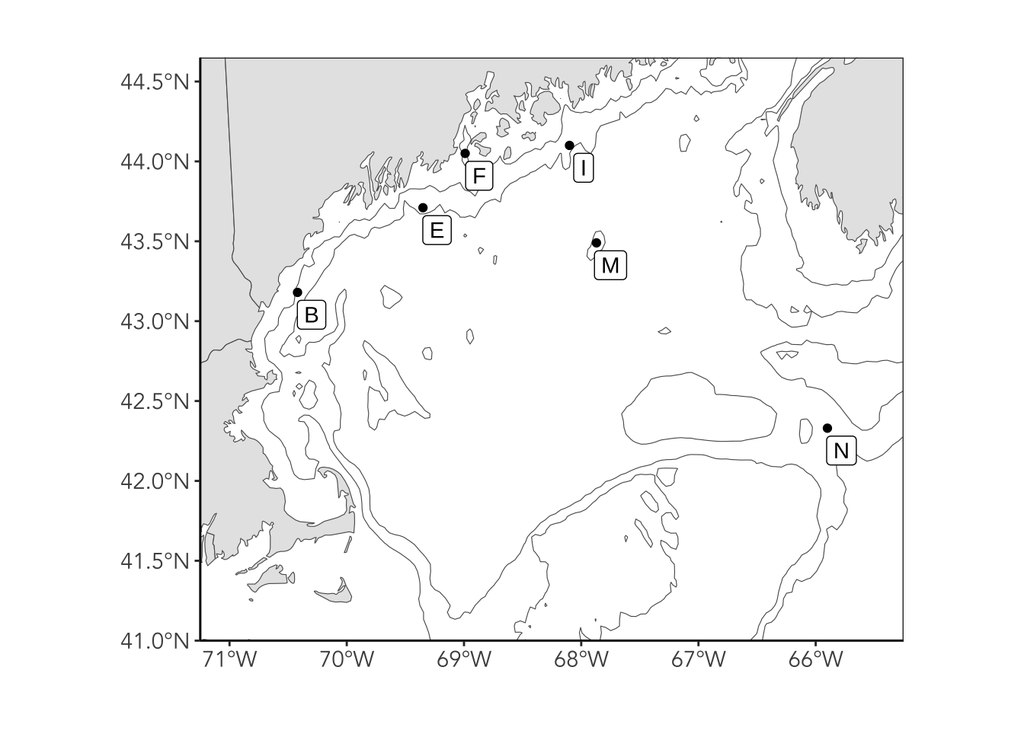

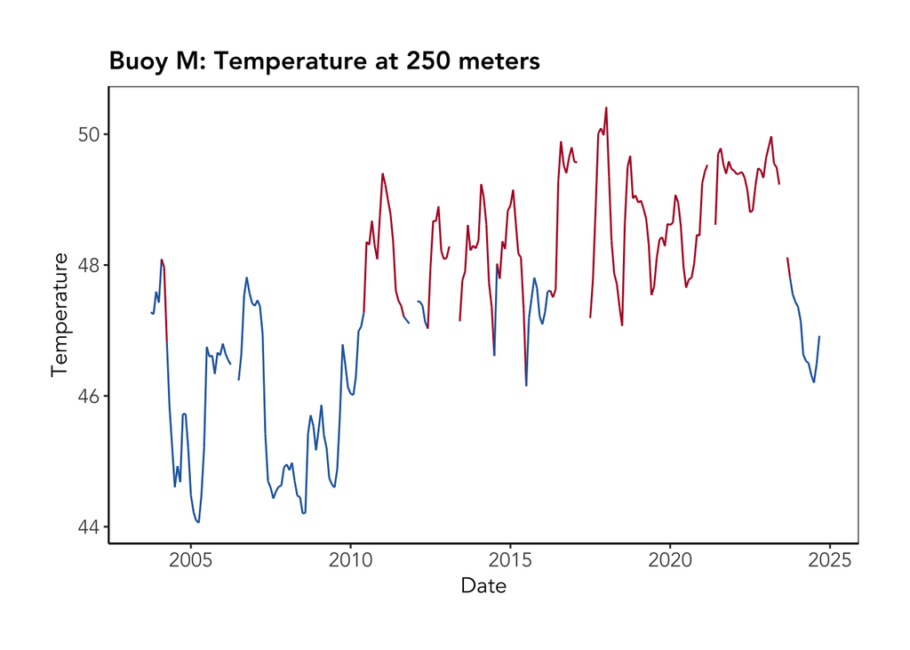

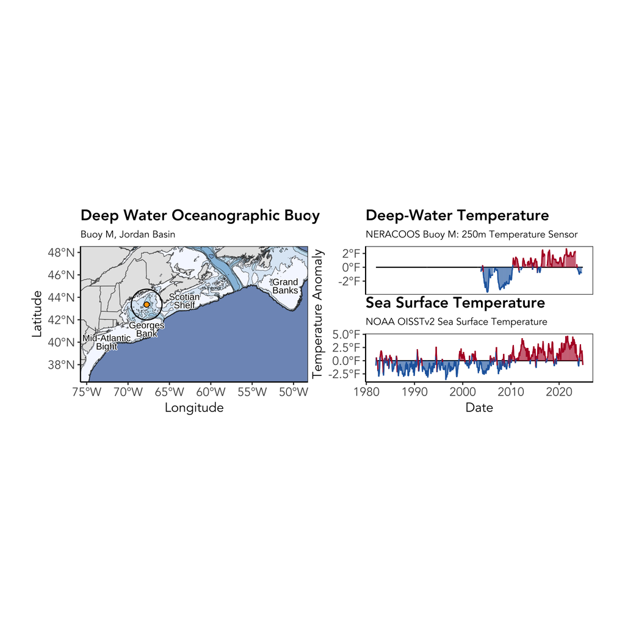

### Bottom Temperature Reanalysis

Bottom temperatures are not as easily observed or directly measurable, and for tracking broad-scale changes researches rely on modeled data known as ocean reanalyses.

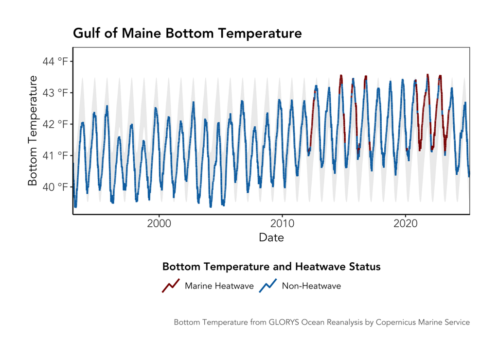

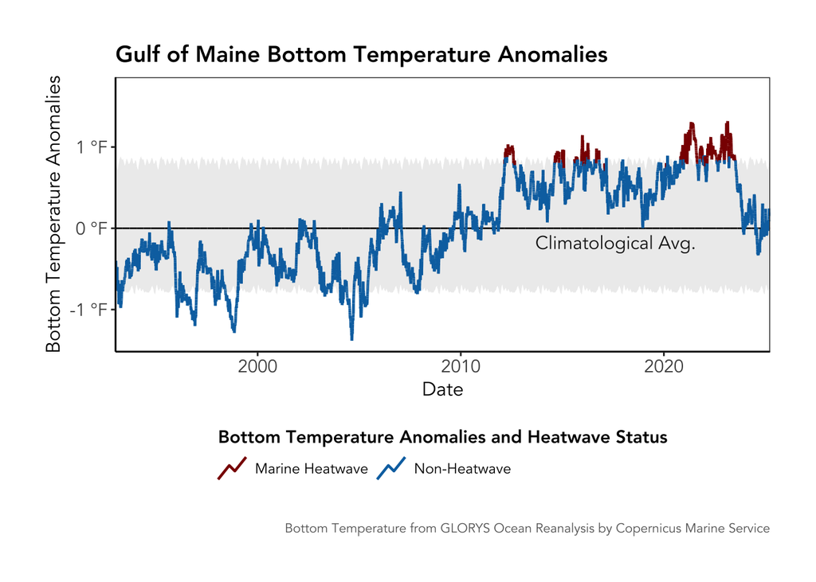

### Regional Bottom Temperature Maps

From an overhead perspective, sea bottom temperatures shifted to cooler temperatures during the Fall of 2023. Bottom temperature anomalies reveal that below average temperatures were concentrated along the shelf break and the Northeast Channel, and extended as far south as off the coast of Maryland.

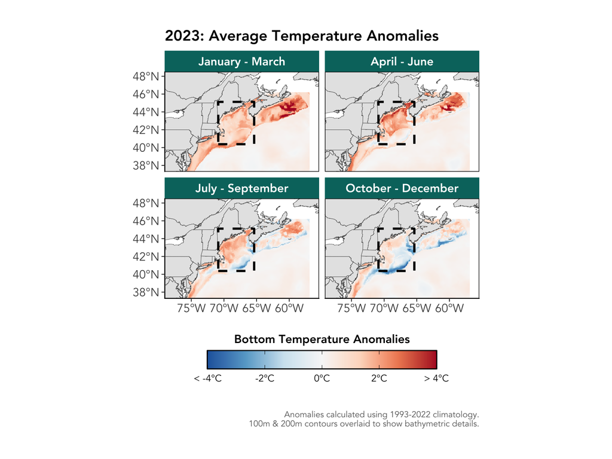

Sea bottom temperature anomalies during 2024 reveal that the below-average temperatures became more widespread, with above average sea bottom temperatures concentrated along more near-shore areas.

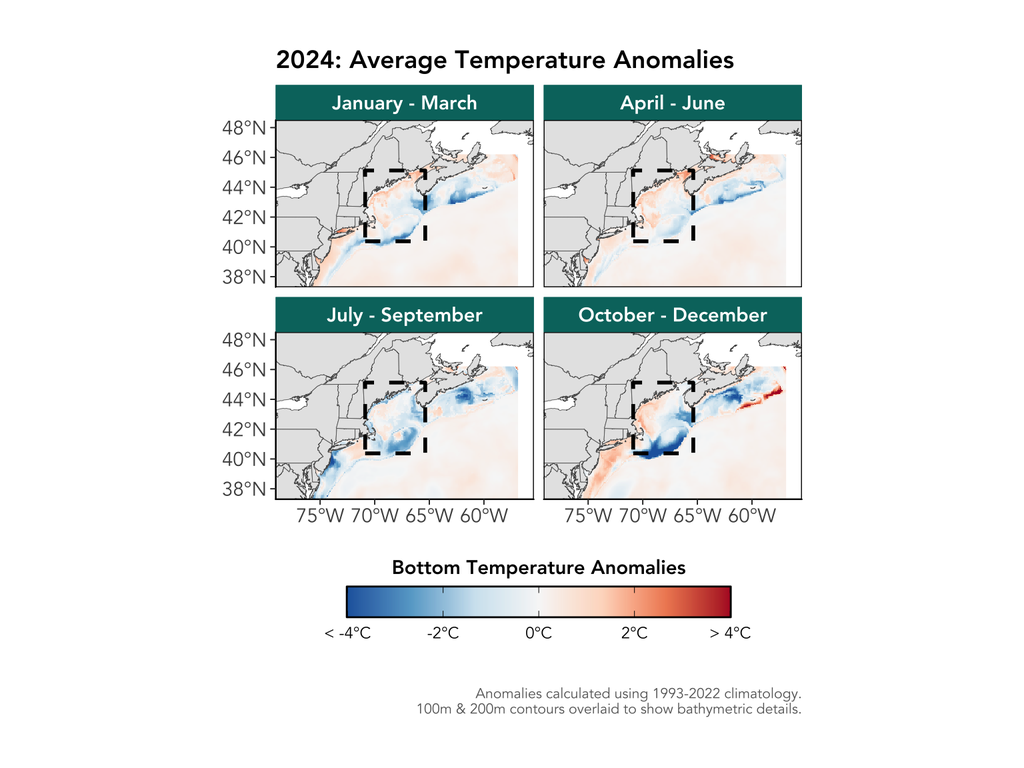

The difference in bottom temperatures between these two years shows us that sea bottom temperatures fell broadly, and for many areas this difference was several degrees (C).

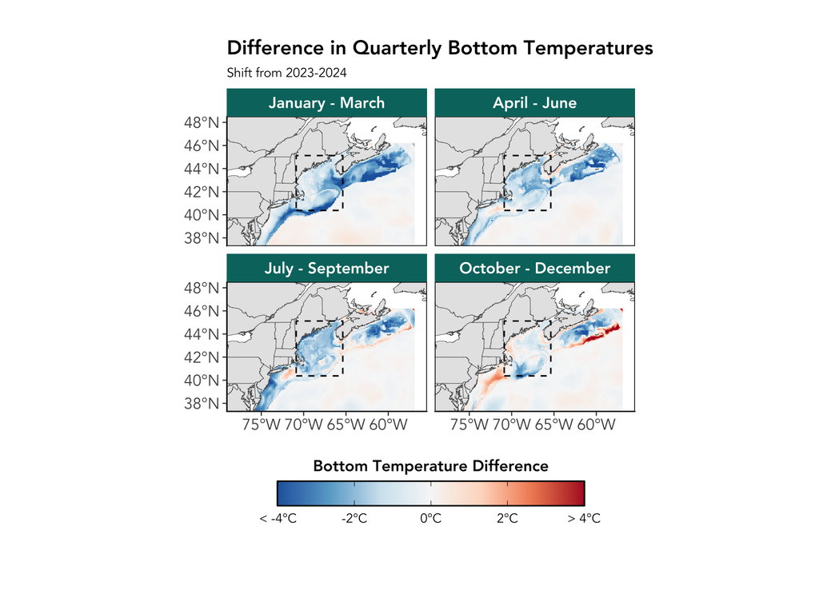

### Gulf Stream Positioning

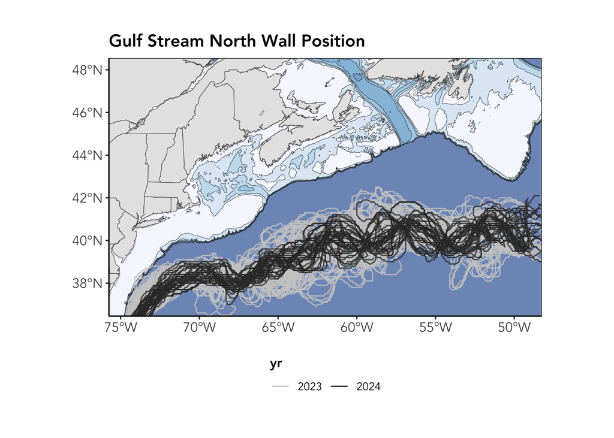

[figure not shown]

## The Importance of the Gulf of Maine Region

For analyses like these that characterize environmental conditions for a particular area—in this case, the Gulf of Maine—it is important to be clear about the spatial extent that defines the region of study; different domain boundaries could produce different results. The spatial area we use to define the “Gulf of Maine” is displayed in Figure 13, and has remained consistent throughout our seasonal and annual warming updates.

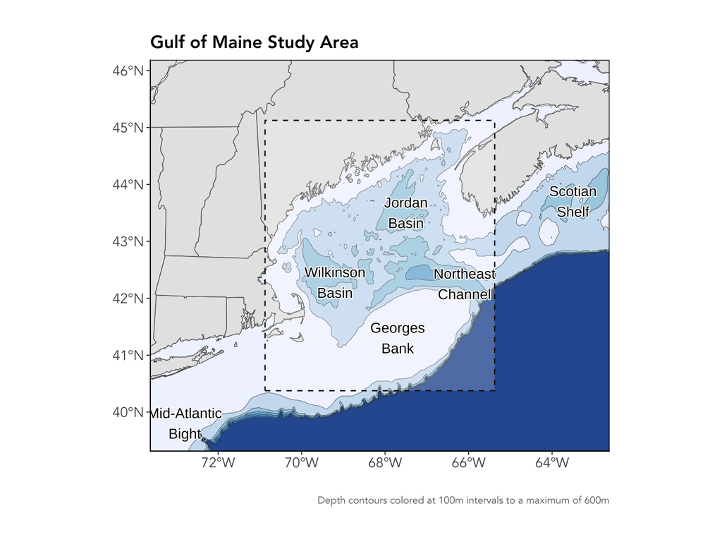

Figure 13: Spatial domain used for Gulf of Maine SST analyses. Dashed line denotes the region of study for this analysis. Depth contours are colored at 100m intervals to a maximum of 600m, deeper blues indicate deeper water depths.

**A Note on Data Sources**

The figures in this report are created using remotely-sensed satellite data as part of publicly funded research efforts. Satellite SST data was obtained from NOAA’s National Center for Environmental Information (NCEI), with all maps and figures displaying NOAA’s Optimum Interpolation Sea Surface Temperature Data.

- NOAA High Resolution SST data provided by the NOAA/OAR/ESRL PSL, Boulder, Colorado, USA, from their Web site at https://psl.noaa.gov/data/gridded/data.noaa.oisst.v2.highres.html.

**Recommended Citation:**

> Gulf of Maine Research Institute. 2024. Gulf of Maine Warming Update: 2024. https://gmri.org/stories/warming-22

A work by [Adam A. Kemberling](https://github.com/adamkemberling/)

*Akemberling@gmri.org*